# Principal component analysis (PCA)

## Where does the map mislead?

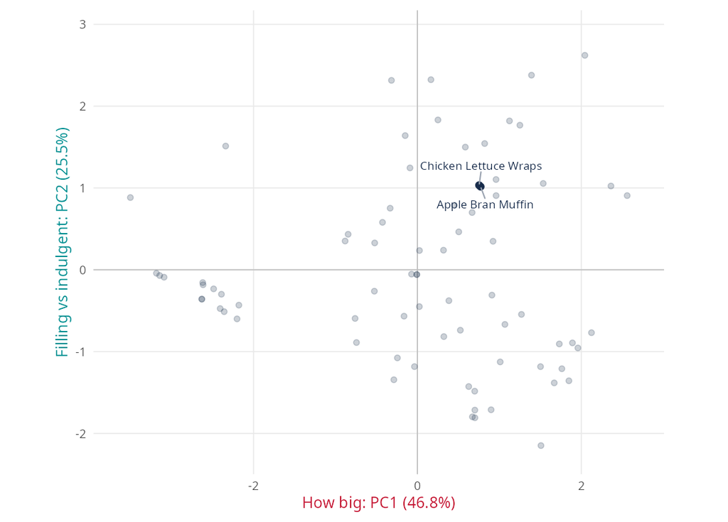

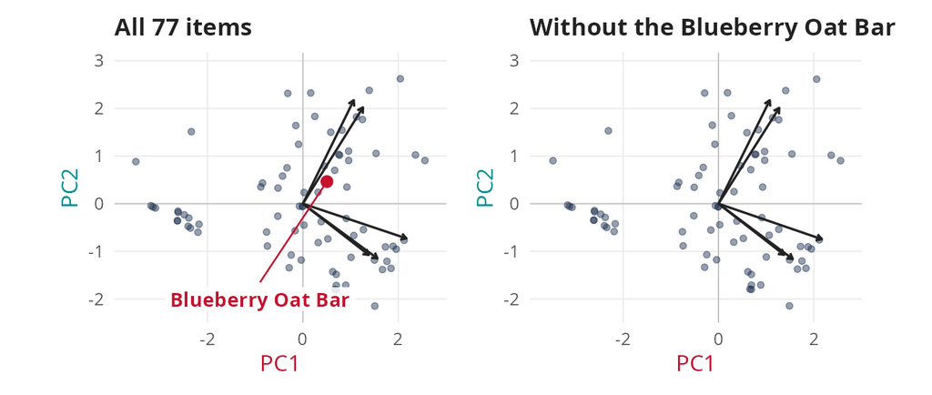

Drop the most unusual item and the map barely moves. On this menu that's not a problem. In other data, a single extreme record can turn the whole map. Look at the extremes before you trust it.

Same spot on the map. Same food?

|  | calories | fat (g) | carb (g) | fiber (g) | protein (g) |
| --- | --- | --- | --- | --- | --- |
| Apple Bran Muffin | 350 | 9 | 64 | 7 | 6 |
| Chicken Lettuce Wraps | 360 | 19 | 32 | 4 | 17 |

## How do we run this in R?

```r
sb <- read.csv("starbucks_clean.csv")   # the menu file
X <- sb[, c("calories", "fat", "carb", "fiber", "protein")]   # the five nutrition numbers
pca <- prcomp(X, scale. = TRUE)   # each number in SDs
summary(pca)   # share of the spread for each component
round(pca$rotation[, 1:2], 2)   # loadings of PC1 and PC2
```

```
Importance of components:
                          PC1    PC2    PC3     PC4     PC5
Standard deviation     1.5304 1.1300 0.9977 0.61660 0.07218
Proportion of Variance 0.4684 0.2554 0.1991 0.07604 0.00104
Cumulative Proportion  0.4684 0.7238 0.9229 0.99896 1.00000
           PC1   PC2
calories -0.63 -0.21
fat      -0.46 -0.33
carb     -0.40 -0.31
fiber    -0.31  0.63
protein  -0.37  0.59
```

Why are all of R’s PC1 loadings negative?

## What should we check before trusting a PCA map?

1. **Is there an outcome you want to predict? PCA never sees one.** A component can hold a large share of the spread and still predict nothing. Here, PC1 holds 46.8%, and the dataset has no sales. Slide 17
2. **Are the numbers in different units? Put them in standard deviations first, or the number with the biggest spread takes over.** In raw units, calories took 98.0%. In standard deviations, PC1 holds 46.8%. Slide 12
3. **Is the data skewed, or are there extreme points? They can pull the directions.** Here they don’t: dropping the most unusual item, the Blueberry Oat Bar, moves the loadings by less than 0.01. Slide 18
4. **Do the names fit both the loadings and the points at each end?** How big and filling against indulgent fit both. Slides 14 and 15
5. **How many components does your use need? Read the cumulative share.** Two keep 72.4%, and three keep 92.3%. Slide 17

## Can two numbers per item, built from these five variables, show which items are alike and what kind of item is missing?

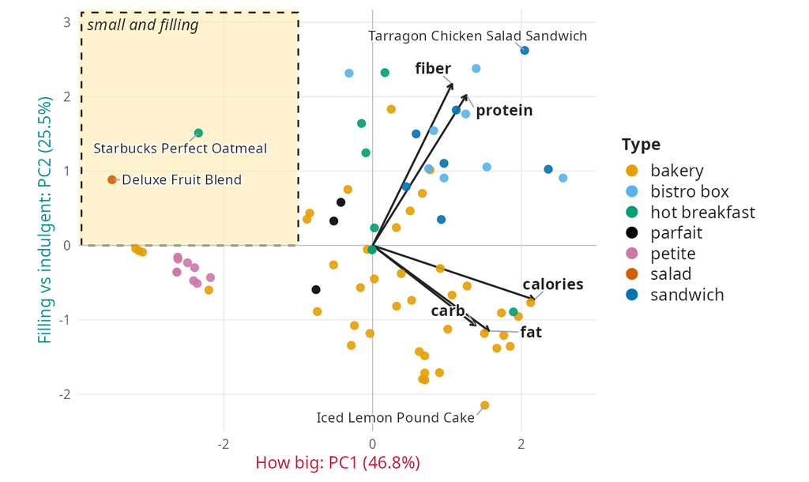

1. **PCA turns many numbers into a few that keep most of the spread.** Here, five numbers per item become two, how big and filling against indulgent, and they keep 72.4%.
2. **Points close together on the map are alike on what the map keeps.** Close items are candidates to replace each other when one is dropped, but check all five numbers first. Slide 18
3. **An empty part of the map points to something no one offers yet.** Of the 15 clearly small items, only 2 are on the filling side. That’s where a new item could go.
4. **The trade-off is that the map is easy to read but leaves part of the spread out.** Here, 27.6% is left out, and the map says nothing about what sells.

## What would a third number add?

Backup: from slide 17

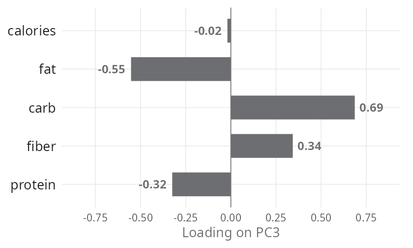

## What does the map look like on the raw numbers?

Backup: from slide 12

[figure not shown]